# ER model for NHC

Alice Carter

2/2022

## Overview

We are building a model of ecosystem respiration based on physical drivers using our modern dataset from New Hope Creek. We will then use this model to predict respiration rates that we would have expected in 1969 based on this modern understanding. To test our understanding of how the ecosystem metabolism has changed over 50 years, we will compare these predictions to measured rates of ER in the past.

Outline:  
1. Build a state space model of respiration as a function of discharge, water temperature, and litterfall with a latent carbon storage state.  
2. Test model on simulated data.  
3. Adapt model to incorporate missing data.  
4. Fit model to modern NHC data at one site.

Next steps:  
- Expand model to a hierarchical structure that allows for information sharing across sites.  
- Use model to predict rates of ER in the past.  
- Compare monthly averaged rates to measured past values.

## Model Description

We will model respiration ($R$) as a function of the productivity ($P$), the carbon storage available for respiration ($C$), and a temperature ($T$) dependent decomposition rate ($K$). The carbon stored in the stream is a latent state in the model that will evolve as a random walk with removal through discharge and respiration, and additions through annual litterfall ($L$).

#### Process model

$K_t = K_{20} \times e^{\frac{-E}{k_b}(\frac{1}{T_t} - \frac{1}{293})}$

$R_t = - AR \times P_t - C_t * K_t$

$C_t = (C_{t-1} + P_{t-1} + L_t + R_{t-1}) \times (1 - \beta Q_t) \times \epsilon_t$

$\epsilon_t \sim lognormal(0, \sigma_{proc})$

#### Observation model

$R_{obs,t} \sim N(R_t, \sigma_{obs})$

## Simulate data

Use real input data to simulate ER and GPP:

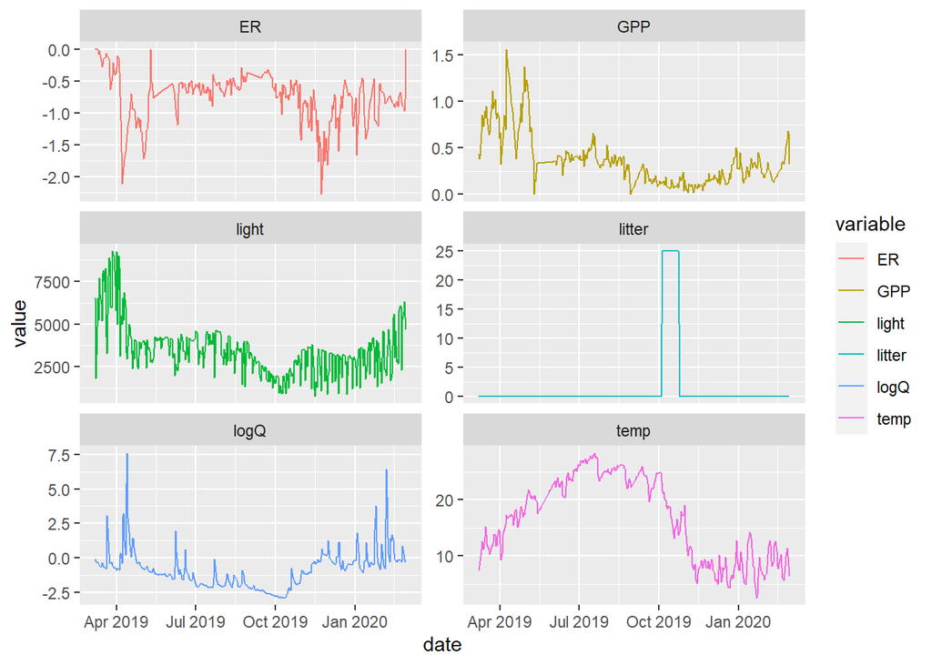

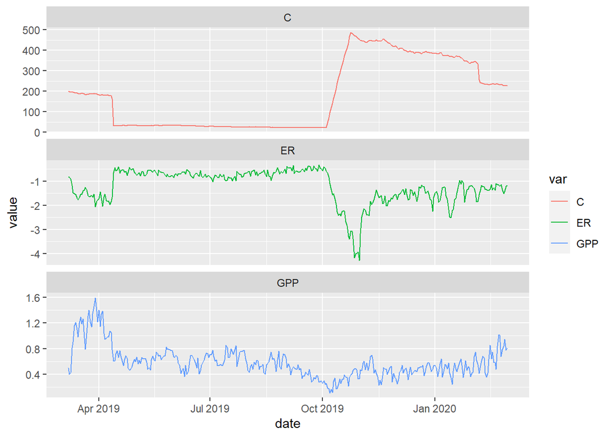

```r
N <- nrow(cbp)
light = cbp$PAR_surface/max(cbp$PAR_surface)
Q = cbp$discharge/max(cbp$discharge)
temp = cbp$temp.water + 273
litter = cbp$litter

# simulate GPP
P <- numeric()
P[1] = 0.5
for(i in 2:N){
  P[i] = 0.5 * P[i-1] + 0.8 * light[i] + rnorm(1,0, 0.05)
}

# define parameters
K20 = .01  # Heterotrophic respiration at 20 C
beta = 0.8   # Percent removal of organic carbon from max storm
sigma_proc = .01
sigma_obs = 0.08

# Constants
E = 0.63              # activation energy for heterotrophic respiration
k_b = 8.6173 * 10^-5  # Boltzmann's constant in eV/K
AR = 0.5              # the fraction of GPP respired by autotrophs

# Process model
C = numeric()
R = numeric()
R_obs = numeric()
K_t = numeric()
C[1] = 200 # initial accessible carbon storage in stream
K_t[1] = K20 * exp(-E/k_b *(1/temp[1] - 1/293))
R[1] = -AR * P[1] - K_t[1] * C[1]

for(i in 2:N){
  C[i] = exp(rnorm(1, log((C[i-1] + litter[i] + R[i-1] + P[i-1])*(1-beta*Q[i])), sigma_proc))
  K_t[i] = K20 * exp(-E/k_b * (1/temp[i] - 1/293))
  R[i] = -AR * P[i] - K_t[i]*C[i]
}

R_obs = rnorm(N, R, sigma_obs)

cbp_mod <- data.frame(date = cbp$date, GPP = P, ER = R_obs, C = C)

pivot_longer(cbp_mod, -date, names_to = 'var', values_to = 'value') %>%
  ggplot(aes(date, value, col = var)) +
  geom_line()+
  facet_wrap(.~var, scales = 'free_y', nrow = 3)
```

## State space ER model:

### Stan Code

```
data {
  int<lower=0> N; // number of observations
  vector<upper=0>[N] R_obs; // ER
  vector<lower=0>[N] P_obs; // GPP
  vector<lower=0>[N] tempK; // water temperature in K
  vector<lower=0>[N] Q; // discharge
  vector<lower=0>[N] litter; // daily carbon input
  real<lower=0> C0; // initial carbon storage
}

parameters {
  //real<lower=0> R20;
  real<lower=0,upper=1> beta;
  real<lower=0> sigma_proc;
  real<lower=0> sigma_obs;
  vector<lower=0>[N] C; // organic carbon
}

transformed parameters{

}

model {
  // Process model
  real k_b;     // Boltzman's constant in eV/K
  real AR;      // Fraction of GPP that is respired by autotrophic respiration
  real E;       // activation energy
  real K_20;
  vector[N] R;  // actual respiration (unobserved)
  vector[N] K;  // decay rate of organic carbon

  k_b = 8.6173 * 10^-5;
  AR = 0.5;
  E = 0.63;
  K_20 = 0.01;

  //initialize
  C[1] ~ lognormal(log(C0), sigma_proc);
  R[1] = R_obs[1];


  // iterate through timesteps:
  for(i in 2:N){
    C[i] ~ lognormal(log((C[i-1] + litter[i] + R[i-1] + P_obs[i-1])*(1 - beta*Q[i])), sigma_proc);
    K[i] = K_20 * exp(-E/k_b * (1/tempK[i] - 0.003412969));
    R[i] = -AR * P_obs[i] - K[i] * C[i];
  }

  // Observation Model:
  R_obs ~ normal(R, sigma_obs);

  // Priors:
  beta ~ uniform(0, 1);
  sigma_obs ~ normal(0.08, 0.02);
  sigma_proc ~ normal(0,0.05);
  C ~ lognormal(4.5, 0.75);
}
```

```r
stan_dat <- list(N = length(R_obs), R_obs = R_obs, P_obs = P,
                 tempK = temp, Q = Q, litter = litter, C0 = C[1])

mod2 <- stan('src/model/stan/ss_ER.stan',
            data = stan_dat, init = 0,
            chains = 4, cores = 4,
            warmup = 500, iter = 1000)
```

```
## Inference for Stan model: ss_ER.
## 4 chains, each with iter=1000; warmup=500; thin=1;
## post-warmup draws per chain=500, total post-warmup draws=2000.
##
##            mean se_mean   sd 2.5%  25%  50%  75% 97.5% n_eff Rhat
## beta       0.80       0 0.01 0.77 0.79 0.80 0.81  0.82   742 1.00
## sigma_obs  0.08       0 0.00 0.07 0.08 0.08 0.08  0.08  1340 1.00
## sigma_proc 0.01       0 0.00 0.01 0.01 0.01 0.01  0.02    29 1.08
##
## Samples were drawn using NUTS(diag_e) at Wed Mar 09 12:36:52 2022.
## For each parameter, n_eff is a crude measure of effective sample size,
## and Rhat is the potential scale reduction factor on split chains (at
## convergence, Rhat=1).
```

```
## ci_level: 0.8 (80% intervals)
```

```
## outer_level: 0.95 (95% intervals)
```

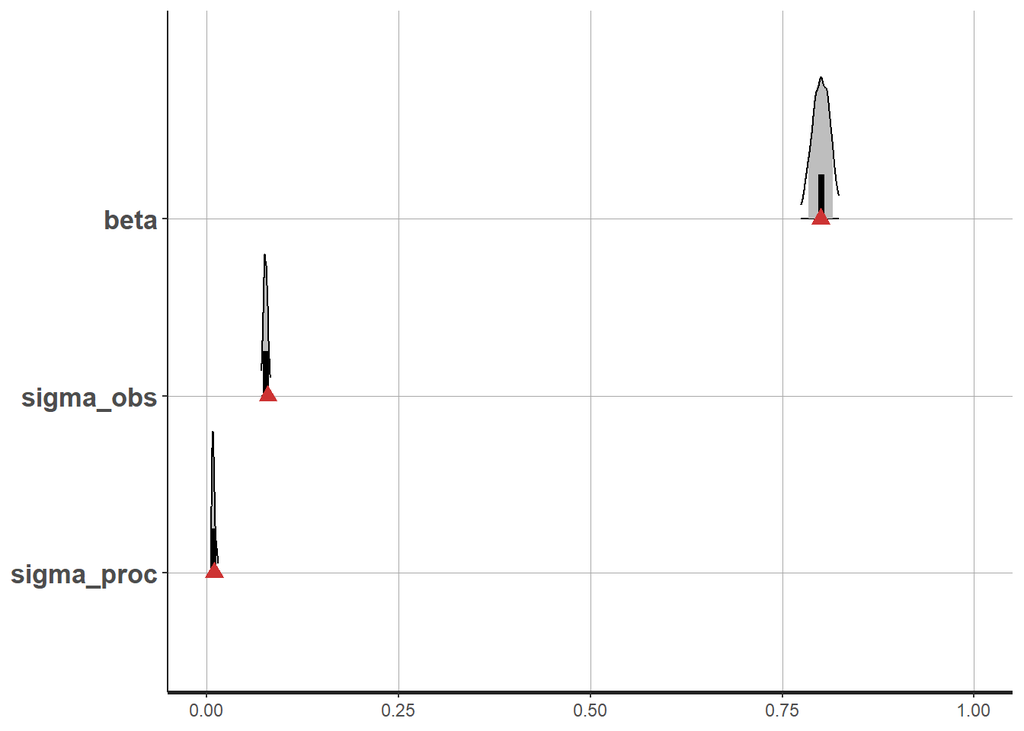

## Model run on NHC data

```r
stan_dat <- list(N = nrow(cbp), R_obs = cbp$ER, P_obs = cbp$GPP,
                 tempK = cbp$tempK, Q = cbp$discharge/max(cbp$discharge),
                 litter = cbp$litter, C0 = 200)

cbp_mod <- stan('src/model/stan/ss_ER.stan',
                data = stan_dat, init = 0,
                chains = 4, cores = 4,
                warmup = 500, iter = 2000)
```

```
## Inference for Stan model: ss_ER.
## 4 chains, each with iter=2000; warmup=500; thin=1;
## post-warmup draws per chain=1500, total post-warmup draws=6000.
##
##            mean se_mean   sd 2.5%  25%  50%  75% 97.5% n_eff Rhat
## beta       0.24       0 0.14 0.01 0.12 0.23 0.34  0.53  5437    1
## sigma_obs  0.16       0 0.01 0.14 0.15 0.16 0.16  0.18  2717    1
## sigma_proc 0.19       0 0.01 0.17 0.18 0.19 0.20  0.22  1704    1
##
## Samples were drawn using NUTS(diag_e) at Wed Jun 22 10:32:57 2022.
## For each parameter, n_eff is a crude measure of effective sample size,
## and Rhat is the potential scale reduction factor on split chains (at
## convergence, Rhat=1).
```

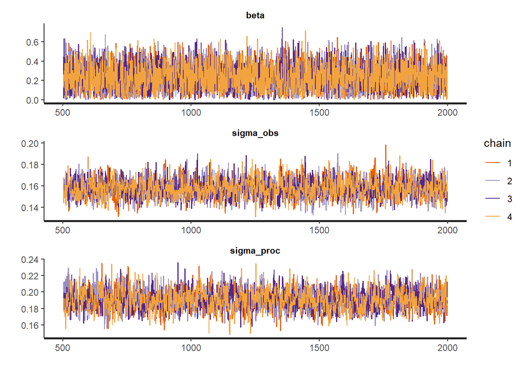

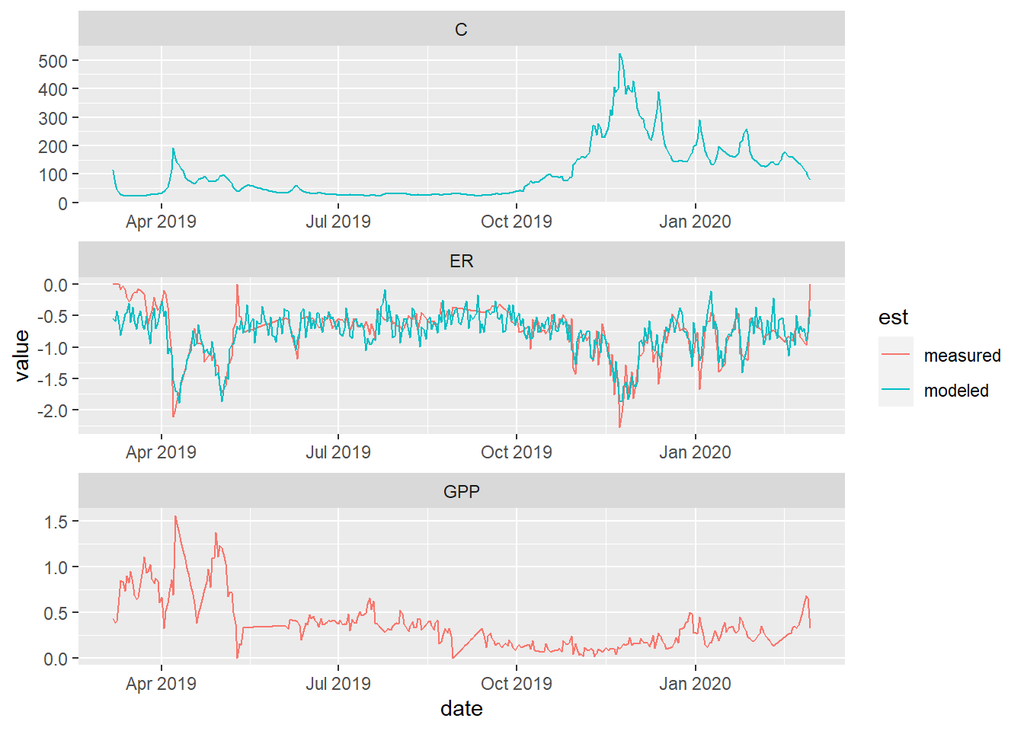

```r
fit <- summary(cbp_mod)
modC <- fit$summary[4:363,1]
modC_sd <- fit$summary[4:363,3]
mod_R <- -AR * cbp$GPP - K20* exp(-E/k_b*(1/cbp$tempK - 1/293)) * modC
mod_R <- rnorm(length(mod_R), mod_R, fit$summary[3,1])

cbp_ests <- cbp %>%
  mutate(C_modeled = modC, ER_modeled = mod_R,
         GPP_modeled = NA_real_, C_measured = NA_real_) %>%
  rename(ER_measured = ER, GPP_measured = GPP)
cbp_ests%>%
  pivot_longer(ends_with(c("_measured", "_modeled")), names_to = c('variable', 'est'),
                         names_sep = '_', values_to = 'value') %>%
  ggplot(aes(date, value, col = est)) +
  geom_line() +
  facet_wrap(.~variable, scales = 'free', ncol = 1)
```

## Missing data model run on NHC data

```r
cbp_miss <- mutate(cbp_miss, miss_vec = ifelse(is.na(ER),1,0))

stan_dat <- list(N = nrow(cbp_miss), R_obs = zoo::na.approx(cbp_miss$ER),
                 P_obs = cbp_miss$GPP, tempK = cbp_miss$tempK,
                 Q = cbp_miss$discharge/max(cbp_miss$discharge),
                 litter = cbp_miss$litter, C0 = 200,
                 miss_vec = cbp_miss$miss_vec)

cbp_miss_mod <- stan('src/model/stan/ss_ER_missingdata.stan',
                data = stan_dat, init = 0,
                chains = 4, cores = 4,
                warmup = 500, iter = 1000)
```

```
## Inference for Stan model: ss_ER_missingdata.
## 4 chains, each with iter=1000; warmup=500; thin=1;
## post-warmup draws per chain=500, total post-warmup draws=2000.
##
##            mean se_mean   sd 2.5%  25%  50%  75% 97.5% n_eff Rhat
## beta       0.36       0 0.19 0.03 0.20 0.36 0.50  0.73  2308 1.00
## sigma_obs  0.21       0 0.01 0.19 0.20 0.21 0.22  0.24   611 1.00
## sigma_proc 0.19       0 0.02 0.16 0.18 0.19 0.20  0.22   315 1.01
##
## Samples were drawn using NUTS(diag_e) at Wed Jun 22 10:38:00 2022.
## For each parameter, n_eff is a crude measure of effective sample size,
## and Rhat is the potential scale reduction factor on split chains (at
## convergence, Rhat=1).
```

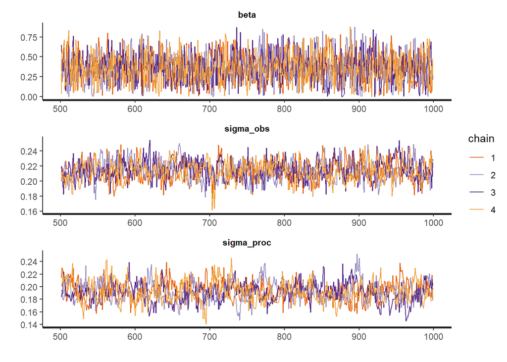

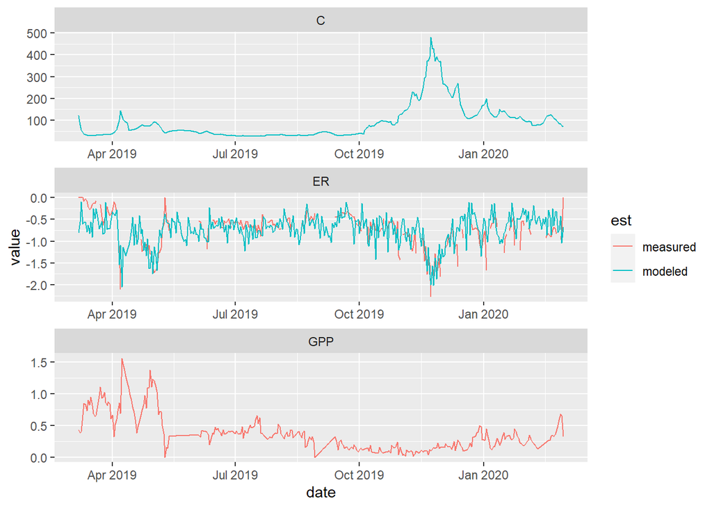

```r
fit <- summary(cbp_miss_mod)
modC <- fit$summary[4:363,1]
modC_sd <- fit$summary[4:363,3]
mod_R <- -AR * cbp_miss$GPP - K20* exp(-E/k_b*(1/cbp_miss$tempK - 1/293)) * modC
mod_R <- rnorm(length(mod_R), mod_R, fit$summary[3,1])

cbp_ests <- cbp_miss %>%
  mutate(C_modeled = modC, ER_modeled = mod_R,
         GPP_modeled = NA_real_, C_measured = NA_real_) %>%
  rename(ER_measured = ER, GPP_measured = GPP)
cbp_ests%>%
  pivot_longer(ends_with(c("_measured", "_modeled")), names_to = c('variable', 'est'),
                         names_sep = '_', values_to = 'value') %>%
  ggplot(aes(date, value, col = est)) +
  geom_line() +
  facet_wrap(.~variable, scales = 'free', ncol = 1)
```

### Compare predictions today and in 1970

```r
hall_dat <- read_csv('data/hall/hall_discharge_temp_daily.csv')
```

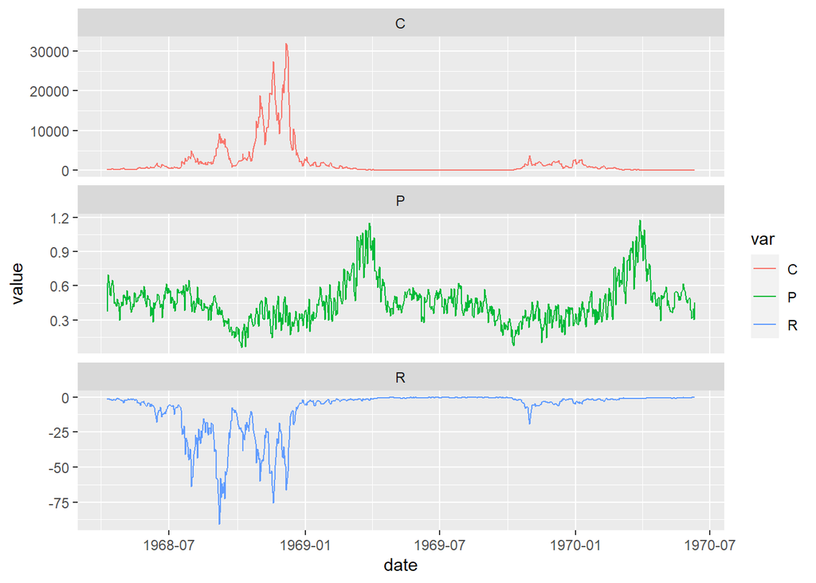

```r
light <- cbp %>% mutate(doy = as.numeric(format(date, '%j'))) %>%
  select(doy, PAR_surface) %>%
  group_by(doy) %>%
  summarize(PAR_surface = mean(PAR_surface, na.rm = T))
hall_dat <- hall_dat %>%
  mutate(doy = as.numeric(format(date, '%j')),
         litter = case_when(doy >= 278 &
                              doy <= 297 ~ 25,
                            TRUE ~ 0),
         logQ = log(discharge_m3s)) %>%
  left_join(light, by = 'doy') %>%
  select(-notes) %>%
  mutate(across(-date, zoo::na.approx, na.rm = F)) %>%
  slice(1:836)


N <- nrow(hall_dat)
light = zoo::na.approx(hall_dat$PAR_surface/max(hall_dat$PAR_surface, na.rm = T), na.rm = F)
Q = zoo::na.approx(hall_dat$discharge_m3s/max(hall_dat$discharge_m3s, na.rm = T), na.rm = F)
temp = zoo::na.approx(hall_dat$water_temp_C, na.rm = F) + 273
litter = hall_dat$litter

# simulate GPP
P_hall <- numeric()
P_hall[1] = 0.5
for(i in 2:N){
  P_hall[i] = 0.5 * P_hall[i-1] + 0.8 * light[i] + rnorm(1,0, 0.05)
}
P_hall <- P_hall * .75
# define parameters
K20 = .01  # Heterotrophic respiration at 20 C
beta = 0.2   # Percent removal of organic carbon from max storm
sigma_proc = 0.22
sigma_obs = 0.16

# Constants
E = 0.63              # activation energy for heterotrophic respiration
k_b = 8.6173 * 10^-5  # Boltzmann's constant in eV/K
AR = 0.5              # the fraction of GPP respired by autotrophs

# Process model
C_hall = numeric()
R_hall = numeric()
R_hall_obs = numeric()
K_t = numeric()
C_hall[1] = 200 # initial accessible carbon storage in stream
K_t[1] = K20 * exp(-E/k_b *(1/temp[1] - 1/293))
R_hall[1] = -AR * P_hall[1] - K_t[1] * C_hall[1]

for(i in 2:N){
  C_hall[i] = exp(rnorm(1, log((C_hall[i-1] + litter[i] + R_hall[i-1] + P_hall[i-1])*(1-beta*Q[i])), sigma_proc))
  K_t[i] = K20 * exp(-E/k_b * (1/temp[i] - 1/293))
  R_hall[i] = -AR * P_hall[i] - K_t[i]*C_hall[i]
}

R_hall_obs = rnorm(N, R_hall, sigma_obs)

data.frame(date = hall_dat$date, P = P_hall, R = R_hall_obs, C = C_hall) %>%
  pivot_longer(-date, names_to = 'var', values_to = 'value') %>%
  ggplot(aes(date, value, col = var)) +
  geom_line()+
  facet_wrap(.~var, scales = 'free_y', nrow = 3)
```

### Metabolism hindcast:

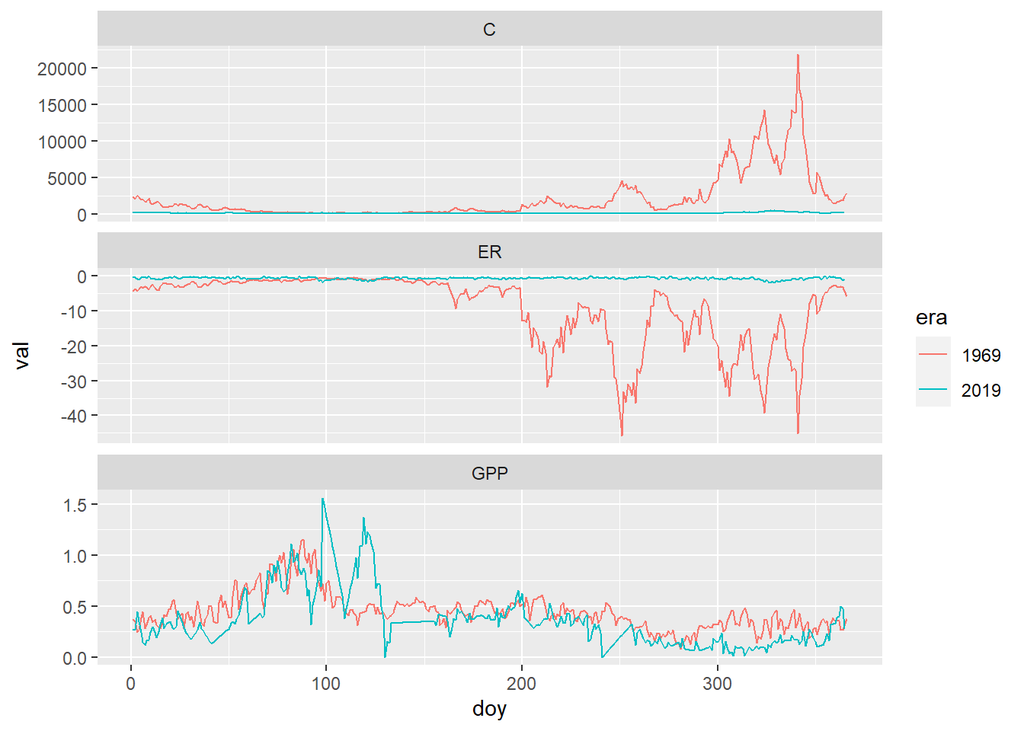

```r
hall <- hall_dat %>%
  mutate(ER = R_hall_obs,
         GPP = P_hall,
         C = C_hall) %>%
  group_by(doy) %>%
  summarize(across(-date, mean, na.rm = T))%>%
  ungroup() %>%
  mutate(era = "1969")

comp <- cbp_ests %>%
  mutate(doy = as.numeric(format(date, '%j'))) %>%
  group_by(doy) %>%
  summarize(across(-date, mean, na.rm = T)) %>%
  ungroup() %>%
  mutate(era = "2019") %>%
  rename(GPP = GPP_measured, ER = ER_modeled, C = C_modeled) %>%
  bind_rows(hall) %>%
  pivot_longer(cols = c('GPP', 'ER', 'C'), names_to = 'variable', values_to = 'val')

comp %>%
  ggplot(aes(doy, val, col = era)) +
  geom_line()+
  facet_wrap(.~variable, scales = 'free_y', nrow = 3)
```

### Next steps:

1. Implement missing data code to estimate missing parameters
2. Incorporate a model for GPP
3. Fix discharge and eliminate unrealistic metabolism estimates
4. Run across sites
5. Add hierarchical variable to describe geomorphology across sites
6. compare differenced ER timeseries with modeled.